# Научная презентация

Дисциплина:Операционные системы

Абрамова У. М.

Российский университет дружбы народов, Москва, Россия

Математический институт имени Никольского, Москва, Россия

07.03.2025

# Информация

## Докладчик

- Абрамова Ульяна Михайловна
- Студент НММбд-01-24
- Российский университет дружбы народов
- 1132246782@pfur.ru
- https://github.com/Ulyana-abr

# Вводная часть

## Актуальность

- В наше время необходимо иметь несколько ОС для различных видов деятельности. Для того, чтобы быстро и удобно переключаться между ними, мы используем виртуальную машину.

## Цели и задачи

- Целью данной работы является приобретение практических навыков установки операционной системы на виртуальную машину, настройки минимально необходимых для дальнейшей работы сервисов.

## Материалы и методы

- Файл установщик VB
- ISO файл FedoraSwaySpin41

## Содержание исследования

1. Установка Linux на Virtualbox Virtualbox был установлен в прошлом семестре, поэтому перейдем к созданию виртуальной машины (рис.1,2)

[figure not shown]

## Содержание исследования

[figure not shown]

создание виртуальной машины

## Содержание исследования

2. Настройки после установки После установки виртуальной машины, вхожу в OC под заданной при установке учетной записью и устанавливаю драйвера для Virtualbox (рис.3)

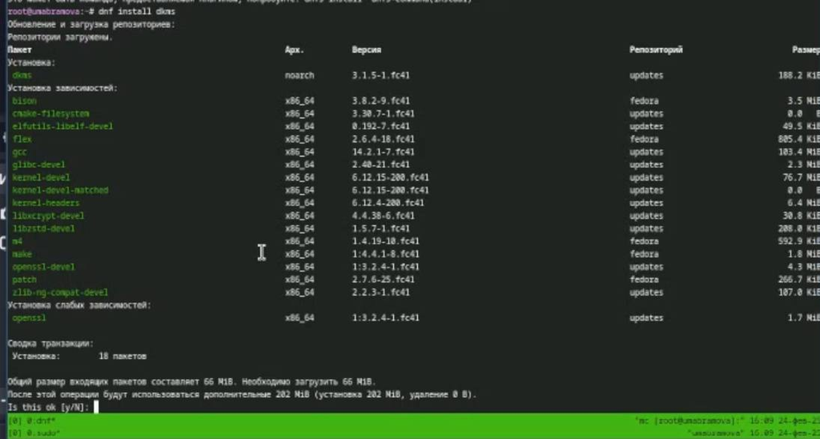

установка драйверов для Virtualbox

## Содержание исследования

Обновляю пакеты (рис.4)

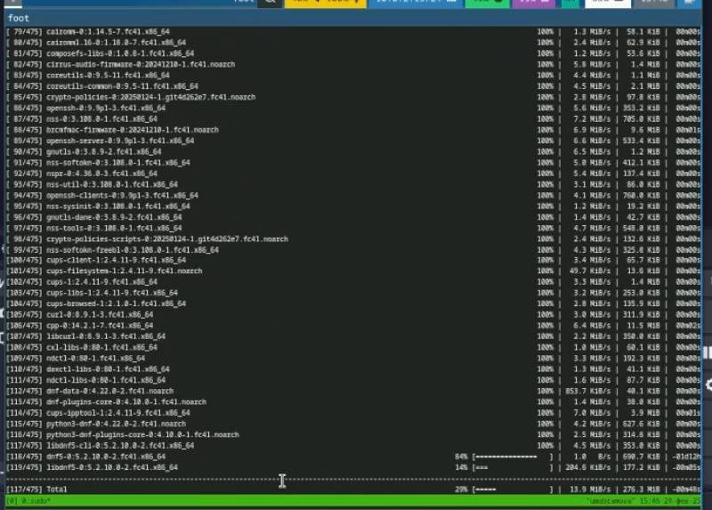

обновление пакетов

## Содержание исследования

Устанавливаю программу для удобства работы в консоли (рис.5)

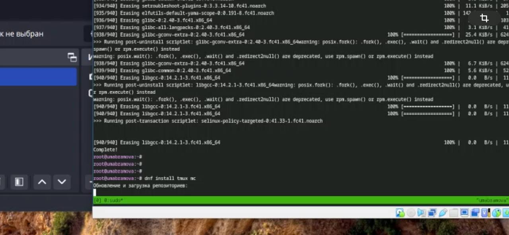

повышение комфорта работы

## Содержание исследования

Настраиваю автоматическое обновление (рис.6)

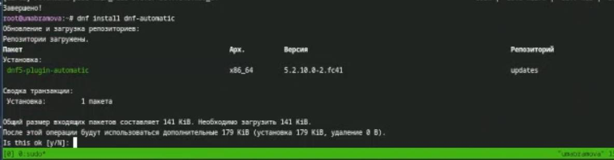

автоматическое обновление

## Содержание исследования

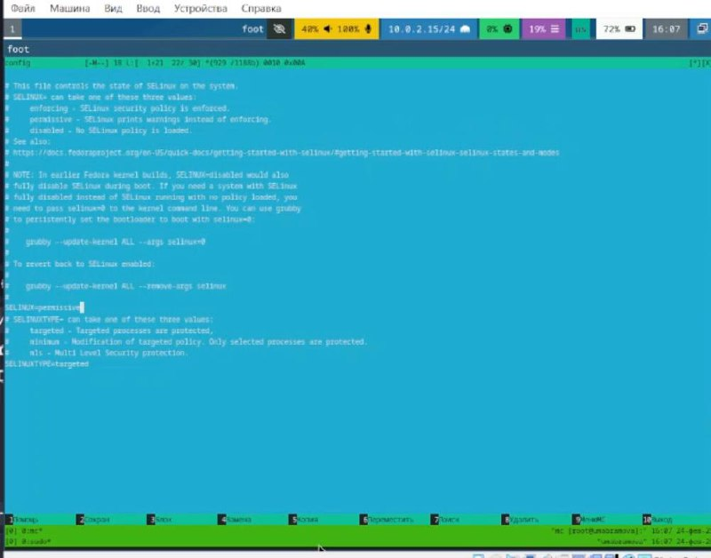

замена значения

## Содержание исследования

Далее настраиваю раскладку клавиатуры (рис.8)

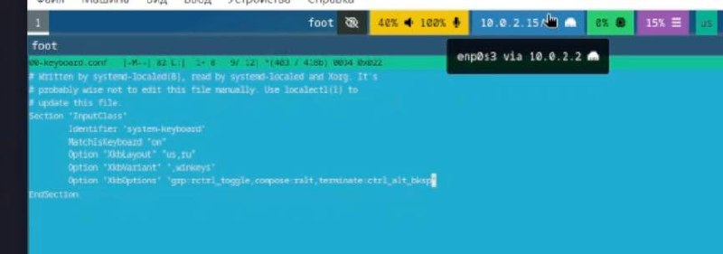

настройка раскладки клавиатуры

## Содержание исследования

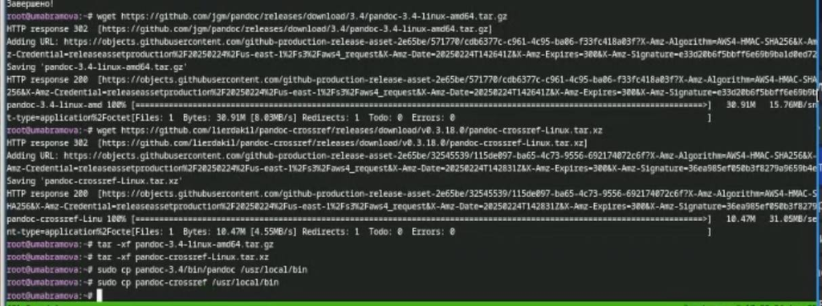

Установка pandoc, pandoc-crossref

## Содержание исследования

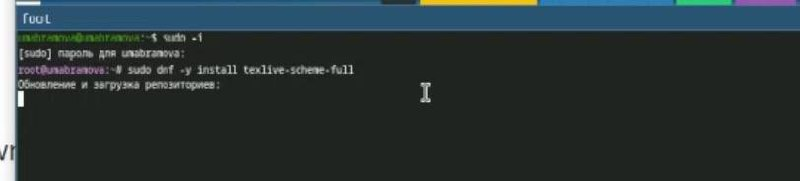

установка texlive

## Содержание исследования

4. Выполнение заданий для самостоятельной работы Выполняя команду dmesg | grep -i “то,что ищем”, получаю информацию о версии ядра Linux, частоте и модели процессора, объеме доступной оперативной памяти, типе обнаруженного гипервизора и файловой системы корневого раздела и последовательности монтирования файловых систем (рис.11,12)

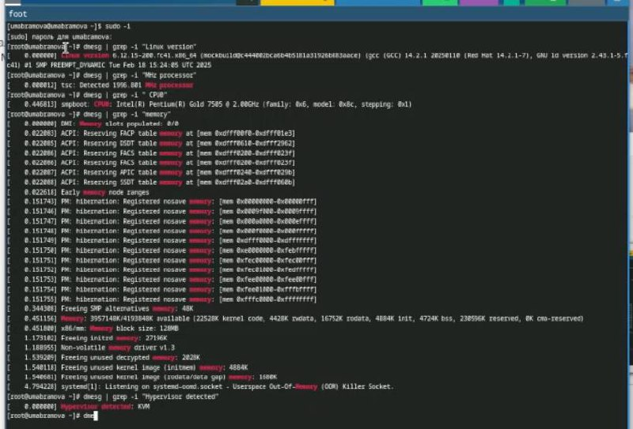

Выполнение команд dmesg | grep -i “то,что ищем”

## Содержание исследования

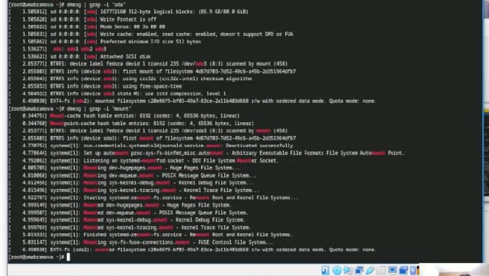

Выполнение команд dmesg | grep -i “то,что ищем”

## Результаты

- Я приобрела практические навыки установки операционной системы на виртуальную машину и настройки минимально необходимых для дальнейшей работы сервисов.

## Итоговый слайд

- Чем больше вы практикуетесь и пробуете новое, тем больше и чаще вы будете получать знаний и опыта в разных сферах.